# Lab 01A: Introduction to R

## Vectorized arithmetic

One of the most useful properties of vectors in `R` is that we can use them to simplify basic arithmetic operations that need to be done on multiple observations. For example, consider the following data on wing chord (a measure of wing length) and body mass of Swainson’s thrushes (*Catharus ustulatus*):

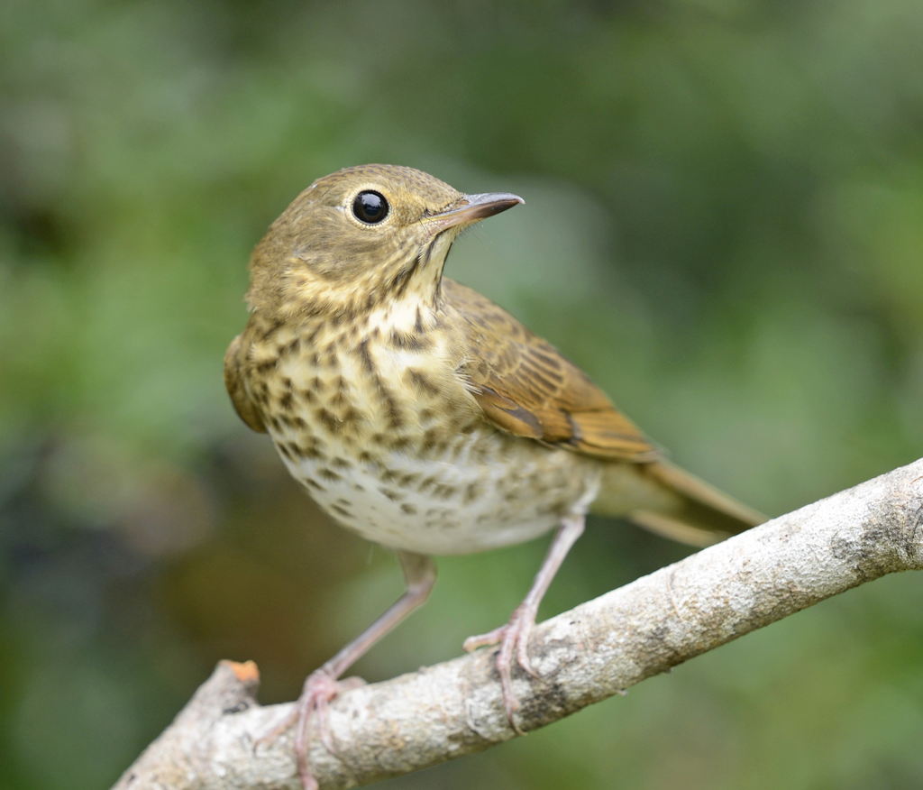

Swainson’s Thrush. Image courtesy of VJAnderson via Wikicommons

Image link

| Individual | Mass (g) | Wing chord (mm) |
| --- | --- | --- |
| 1 | 36.2 | 95.1 |
| 2 | 34.6 | 88.4 |
| 3 | 31.0 | 97.9 |
| 4 | 31.8 | 96.8 |
| 5 | 29.4 | 92.3 |
| 6 | 32.0 | 90.6 |

Perhaps we want to derive the body condition of each individual based on these measures. One common metric of body condition used by ornithologists is $\frac{mass}{size}$, where wing chord is used as a proxy for body size. We *could* calculate body condition for each individual:

```r
cond1 <- 36.2/95.1 # Body condition of the first individual

cond2 <- 34.6/88.4 # Body condition of the second individual
```

But that is time consuming and error prone. Luckily, `R` will *vectorize* basic arithmetic:

```r
mass <- c(36.2, 34.6, 31.0, 31.8, 29.4, 32.0)
wing <- c(95.1, 88.4, 97.9, 96.8, 92.3, 90.6)

cond <- mass/wing
cond
```

```
#> [1] 0.3806519 0.3914027 0.3166496 0.3285124 0.3185265 0.3532009
```

As you can see, when we divide one vector by another, `R` divides the first element of the first vector by the first element of the second vector, etc. and returns a vector.

# Packages

One of `R`’s primary strengths is the large number of *packages* available to users. Packages are units of shareable code and data that have been created by other `R` users. We have already seen the built-in functions that `R` comes with. Packages allow users to share lots and lots of other functions that serve specific purposes. Packages also allow users to share [data sets](https://stat.ethz.ch/R-manual/R-devel/library/datasets/html/00Index.html). There are packages for cleaning data, visualizing data, making maps, fitting specialized models, and basically anything else you can think of.

Accessing the code in a package first requires installing the package. This only needs to be done **once per computer** and is usually done using the `install.packages()` function:

```r
install.packages("dplyr")
```

Note that the name of the package (in this case `dplyr`) must be in quotation marks. Packages installed using `install.packages()` are stored in a centralized repository called CRAN (Comprehensive R Archive Network). Once `dplyr` (or any package) is installed on your computer, you do not need to re-run the `install.packages()` function unless you re-install/update `R` or need to update the package to a newer version.

`dplyr` is a powerful package for summarizing and modifying data which we will use extensively in class. We will have a more thorough introduction to `dplyr` later this semester.

**Note** if you will be using your own personal laptop for this course, you will only need to run the `install.packages()` function once. However, if you will be using the department laptops in class, and then a desktop computer at home or in the library, computer labs, etc., you will need to run `install.packages()` the first time you use each computer. Likewise, if you are using university computers in the library or computer labs, you may need to `install.packages()` each time you log on (it’s unclear if the University IT security procedures will remove these regularly or not).

Installing a package does not automatically make the functions from that package available in a given `R` session. To tell `R` where the functions come from, you must *load* the package using the `library()` function:

```r
library(dplyr)
```

Unlike `install.packages()`, `library()` must be re-run each time you open `R`. Most people include a few calls to `library()` at the beginning of each script so that all packages needed to run the code are loaded at the beginning of the script.

# Data frames

So far, we have only discussed one particular class of `R` object - vectors. Vectors hold a string of values as a single object. Although useful for many applications, vectors are limited in their ability to store multiple types of data (numeric and character).

This is where data frames become useful. Perhaps the most common type data object you will use in `R` is the data frame. Data frames are tabular objects (rows and columns) similar in structure to spreadsheets (think Excel or GoogleSheets). In effect, data frames store multiple vectors - each column of the data frame is a vector. As such, each column can be a different class (numeric, character, etc.) but all values within a column must be the same class. Just as the first row of an Excel spreadsheet can be a list of column names, each column in a data frame has a name that (hopefully) provides information about what the values in that column represent. The names of columns in data frames are often referred to as `variables` while the rows are generally referred to as `observations`.

To see how data frames work, let’s load a data frame called `starwars` that comes with the `dplyr` package.

```r
library(dplyr)
# the data() function loads data sets which are built-in
# or that come with packages
data("starwars")
```

If you ran the `library(dplyr)` function above, you do not strictly need to run it here again, but i included it here to ensure that you have this package loaded. The `data()` function access the built-in data set called `"starwars"` and makes it accessible in your working session. After running that call, you should see a `starwars` data object in your Environment tab.

Note - As discussed above, if you want to access function or data sets that come with packages, you first need to *load* the package in your current working environment. To do that, use the `library()` function, with the unquoted package name as the argument. Once loaded, all of the package’s functions and built-in data sets are available to use.

Alternatively, you can access functions from a given package without loading the package using `package.name::function.name()`. For example, if you want to use the `filter()` function from the `dplyr` package, you could type `dplyr::filter()`. Although less commonly used, this method has a few advantages:

1. Sometimes different packages have functions with the same names. `R` will default to using the function from the package that was loaded last. For example, the `raster` package also has a function called `filter()` so if you load `dplyr` first (using `library()`and then `raster`, `R` will default to using `raster`’s `filter()` function, which could cause problems.
2. If you share your code with others, the `::` method makes it clear which packages are being use for which functions. That additional clarity is often helpful and is the reason I will occasionally use `::` in this course.

To get a quick idea of what information the `starwars` data frame contains, we can use the `names()` function, which returns the names of the columns, and the `head()` and `tail()` functions, which will print the first and last 6 rows of the data frame:

```r
names(starwars)
```

```
#>  [1] "name"       "height"     "mass"       "hair_color" "skin_color"
#>  [6] "eye_color"  "birth_year" "sex"        "gender"     "homeworld"
#> [11] "species"    "films"      "vehicles"   "starships"
```

```r
head(starwars)
```

```
#> # A tibble: 6 x 14
#>   name     height  mass hair_color  skin_color eye_color birth_year sex   gender
#>   <chr>     <int> <dbl> <chr>       <chr>      <chr>          <dbl> <chr> <chr>
#> 1 Luke Sk~    172    77 blond       fair       blue            19   male  mascu~
#> 2 C-3PO       167    75 <NA>        gold       yellow         112   none  mascu~
#> 3 R2-D2        96    32 <NA>        white, bl~ red             33   none  mascu~
#> 4 Darth V~    202   136 none        white      yellow          41.9 male  mascu~
#> 5 Leia Or~    150    49 brown       light      brown           19   fema~ femin~
#> 6 Owen La~    178   120 brown, grey light      blue            52   male  mascu~
#> # ... with 5 more variables: homeworld <chr>, species <chr>, films <list>,
#> #   vehicles <list>, starships <list>
```

```r
tail(starwars)
```

```
#> # A tibble: 6 x 14
#>   name     height  mass hair_color skin_color eye_color birth_year sex    gender
#>   <chr>     <int> <dbl> <chr>      <chr>      <chr>          <dbl> <chr>  <chr>
#> 1 Finn         NA    NA black      dark       dark              NA male   mascu~
#> 2 Rey          NA    NA brown      light      hazel             NA female femin~
#> 3 Poe Dam~     NA    NA brown      light      brown             NA male   mascu~
#> 4 BB8          NA    NA none       none       black             NA none   mascu~
#> 5 Captain~     NA    NA unknown    unknown    unknown           NA <NA>   <NA>
#> 6 Padmé A~    165    45 brown      light      brown             46 female femin~
#> # ... with 5 more variables: homeworld <chr>, species <chr>, films <list>,
#> #   vehicles <list>, starships <list>
```

`names()` just tells us the names of the columns (aka variables) in the data frame. We also get this information from some of the other functions, but it is often helpful to get a reminder on the column names, and the output from `names()` is easier to interpret quickly.

We can see that `starwars` contains 14 columns with information on different characters in the star wars universe. The `head()` and `tail()` functions abbreviated the data presentation and only show the columns that easily fit on your screen. This is because the `starwars` object is a special kind of data.frame called a “tibble”.

```r
class(starwars)
```

```
#> [1] "tbl_df"     "tbl"        "data.frame"
```

If we converted it to be just a data frame, it will show the first rows for all the columns:

```r
head(as.data.frame(starwars))
```

```
#>             name height mass  hair_color  skin_color eye_color birth_year
#> 1 Luke Skywalker    172   77       blond        fair      blue       19.0
#> 2          C-3PO    167   75        <NA>        gold    yellow      112.0
#> 3          R2-D2     96   32        <NA> white, blue       red       33.0
#> 4    Darth Vader    202  136        none       white    yellow       41.9
#> 5    Leia Organa    150   49       brown       light     brown       19.0
#> 6      Owen Lars    178  120 brown, grey       light      blue       52.0
#>      sex    gender homeworld species
#> 1   male masculine  Tatooine   Human
#> 2   none masculine  Tatooine   Droid
#> 3   none masculine     Naboo   Droid
#> 4   male masculine  Tatooine   Human
#> 5 female  feminine  Alderaan   Human
#> 6   male masculine  Tatooine   Human
#>                                                                                                                                       films
#> 1                                           The Empire Strikes Back, Revenge of the Sith, Return of the Jedi, A New Hope, The Force Awakens
#> 2                    The Empire Strikes Back, Attack of the Clones, The Phantom Menace, Revenge of the Sith, Return of the Jedi, A New Hope
#> 3 The Empire Strikes Back, Attack of the Clones, The Phantom Menace, Revenge of the Sith, Return of the Jedi, A New Hope, The Force Awakens
#> 4                                                              The Empire Strikes Back, Revenge of the Sith, Return of the Jedi, A New Hope
#> 5                                           The Empire Strikes Back, Revenge of the Sith, Return of the Jedi, A New Hope, The Force Awakens
#> 6                                                                                     Attack of the Clones, Revenge of the Sith, A New Hope
#>                             vehicles                starships
#> 1 Snowspeeder, Imperial Speeder Bike X-wing, Imperial shuttle
#> 2
#> 3
#> 4                                             TIE Advanced x1
#> 5              Imperial Speeder Bike
#> 6
```

Several other useful functions exist for investigating the structure of data frames such as `str()` and `summary()`. I have not included the output of these in the tutorial, but you should run them to see what values they return.

`str()` tells us about the structure of the data frame, for example which columns are numeric or character class. `summary()` provides some simple summary statistics for each variable.

```r
dim(starwars)
```

```
#> [1] 87 14
```

```r
nrow(starwars)
```

```
#> [1] 87
```

```r
ncol(starwars)
```

```
#> [1] 14
```

### Subsetting data frames

As you will see shortly, one of the most common tasks when working with data frames is creating new objects from *parts* of the full data frame. This task involves subsetting the data frame - selecting specific rows and columns. There are **many** ways of subsetting data frames in `R`, too many to discuss so we will only learn about a few.

#### Selecting columns

First, we may want to select a subset of all of the columns in a big data frame. Data frames are essentially tables, which means we can reference both rows and columns by their number: `data.frame[row#, column#]`. **Note** that you don’t actually type “row#”, you just enter the numer you want. for example, if you want the observation in the 1st row and the first column you would type:

```r
starwars[1,1]
```

```
#> # A tibble: 1 x 1
#>   name
#>   <chr>
#> 1 Luke Skywalker
```

The row and column numbers have to put inside of square brackets following the name of the data frame object. The row number always comes first and the column number second. If you want to select all rows of a specific column, you just leave the `row#` blank. For example, if we wanted a vector containing just the home worlds (the 10th column) of all the characters:

```r
starwars[,10]
```

```
#> # A tibble: 87 x 1
#>    homeworld
#>    <chr>
#>  1 Tatooine
#>  2 Tatooine
#>  3 Naboo
#>  4 Tatooine
#>  5 Alderaan
#>  6 Tatooine
#>  7 Tatooine
#>  8 Tatooine
#>  9 Tatooine
#> 10 Stewjon
#> # ... with 77 more rows
```

We can also select columns using `data.frame$column_name` (where `data.frame` is the name of the data frame object and `column_name` is the name of the column). In this case, you do actually need to type the `$`. For example,

```r
starwars$homeworld
```

```
#>  [1] "Tatooine"       "Tatooine"       "Naboo"          "Tatooine"
#>  [5] "Alderaan"       "Tatooine"       "Tatooine"       "Tatooine"
#>  [9] "Tatooine"       "Stewjon"        "Tatooine"       "Eriadu"
#> [13] "Kashyyyk"       "Corellia"       "Rodia"          "Nal Hutta"
#> [17] "Corellia"       "Bestine IV"     NA               "Naboo"
#> [21] "Kamino"         NA               "Trandosha"      "Socorro"
#> [25] "Bespin"         "Mon Cala"       "Chandrila"      NA
#> [29] "Endor"          "Sullust"        NA               "Cato Neimoidia"
#> [33] "Coruscant"      "Naboo"          "Naboo"          "Naboo"
#> [37] "Naboo"          "Toydaria"       "Malastare"      "Naboo"
#> [41] "Tatooine"       "Dathomir"       "Ryloth"         "Ryloth"
#> [45] "Vulpter"        "Troiken"        "Tund"           "Haruun Kal"
#> [49] "Cerea"          "Glee Anselm"    "Iridonia"       "Coruscant"
#> [53] "Iktotch"        "Quermia"        "Dorin"          "Champala"
#> [57] "Naboo"          "Naboo"          "Tatooine"       "Geonosis"
#> [61] "Mirial"         "Mirial"         "Naboo"          "Serenno"
#> [65] "Alderaan"       "Concord Dawn"   "Zolan"          "Ojom"
#> [69] "Kamino"         "Kamino"         "Coruscant"      "Aleen Minor"
#> [73] NA               "Skako"          "Muunilinst"     "Shili"
#> [77] "Kalee"          "Kashyyyk"       "Alderaan"       "Umbara"
#> [81] "Utapau"         NA               NA               NA
#> [85] NA               NA               "Naboo"
```

Notice that if you hit `tab` after you type the `$`, RStudio will bring up all of the column names in that dataframe and you can use the up or down buttons to find the one you want.

Sometimes you may want to select more than one column. The easiest way to do that is to use the `select()` function in the `dplyr` package. Remember to run `install.packages("dplyr")` before the `library(dplyr)` call below if this is you’re first time using the `dplyr` package on the computer you are using.

```r
library(dplyr)

head(select(.data = starwars, name, height, homeworld))
```

```
#> # A tibble: 6 x 3
#>   name           height homeworld
#>   <chr>           <int> <chr>
#> 1 Luke Skywalker    172 Tatooine
#> 2 C-3PO             167 Tatooine
#> 3 R2-D2              96 Naboo
#> 4 Darth Vader       202 Tatooine
#> 5 Leia Organa       150 Alderaan
#> 6 Owen Lars         178 Tatooine
```

**Quick note** I used the `head()` function around the `select()` function above to shorten the display of the `starwars` to save room. Nesting functions like this (`head(select(...))`) can be very useful. However, it can also be confusing because you have to read the functions “inside out”. Likewise it can be easy to miss or add additional `()` or `,` to either the beginning or the end of the function call. To help reduce this risk, I recommend turning on “rainbow brackets”: 1. Open Global Options from the Tools menu 2. Select Code -> Display 3. Enable the Rainbow Parentheses option at the bottom

Back to the `select()` function…

Notice that select requires us to first provide the data frame object (`.data = starwars`) and then we provide the column names (unquoted!) we want to select. You can also use select to remove columns:

```r
head(select(.data = starwars, -height))
```

```
#> # A tibble: 6 x 13
#>   name    mass hair_color skin_color eye_color birth_year sex   gender homeworld
#>   <chr>  <dbl> <chr>      <chr>      <chr>          <dbl> <chr> <chr>  <chr>
#> 1 Luke ~    77 blond      fair       blue            19   male  mascu~ Tatooine
#> 2 C-3PO     75 <NA>       gold       yellow         112   none  mascu~ Tatooine
#> 3 R2-D2     32 <NA>       white, bl~ red             33   none  mascu~ Naboo
#> 4 Darth~   136 none       white      yellow          41.9 male  mascu~ Tatooine
#> 5 Leia ~    49 brown      light      brown           19   fema~ femin~ Alderaan
#> 6 Owen ~   120 brown, gr~ light      blue            52   male  mascu~ Tatooine
#> # ... with 4 more variables: species <chr>, films <list>, vehicles <list>,
#> #   starships <list>
```

You can also select all the columns that occur between two names using the `:`

```r
head(select(.data = starwars, name:eye_color))
```

```
#> # A tibble: 6 x 6
#>   name           height  mass hair_color  skin_color  eye_color
#>   <chr>           <int> <dbl> <chr>       <chr>       <chr>
#> 1 Luke Skywalker    172    77 blond       fair        blue
#> 2 C-3PO             167    75 <NA>        gold        yellow
#> 3 R2-D2              96    32 <NA>        white, blue red
#> 4 Darth Vader       202   136 none        white       yellow
#> 5 Leia Organa       150    49 brown       light       brown
#> 6 Owen Lars         178   120 brown, grey light       blue
```

It’s important to realize that even though there are different ways to accomplish the same general task (in this case, “subset columns of a data frame”), those methods will sometimes differ in subtle but important ways.

For example, what type of object did the `data.frame[,col#]` and `data.frame$column.name` options return? What type of object did `select(data.frame, col1, col2)` return? Modify the code above by nesting it into the `class()` function to see what type of objects they are.

For example:

```r
class(starwars$homeworld)
```

```
#> [1] "character"
```

```r
class(select(.data = starwars, -height))
```

```
#> [1] "tbl_df"     "tbl"        "data.frame"
```

Those are very different results and knowing what the output will be can be useful when deciding the best way to accomplish your task i.e. if you want to have a vector or data.frame at the end.

#### Filtering rows

To select specific rows, we can use the `[row#, col#]` method we learned above, this time leaving the columns blank:

```r
starwars[1,]
```

```
#> # A tibble: 1 x 14
#>   name     height  mass hair_color skin_color eye_color birth_year sex   gender
#>   <chr>     <int> <dbl> <chr>      <chr>      <chr>          <dbl> <chr> <chr>
#> 1 Luke Sk~    172    77 blond      fair       blue              19 male  mascul~
#> # ... with 5 more variables: homeworld <chr>, species <chr>, films <list>,
#> #   vehicles <list>, starships <list>
```

If we want more than one row, we just put in a vector with all of the rows we want:

```r
# rows 1 and 2
starwars[1:2,]
```

```
#> # A tibble: 2 x 14
#>   name     height  mass hair_color skin_color eye_color birth_year sex   gender
#>   <chr>     <int> <dbl> <chr>      <chr>      <chr>          <dbl> <chr> <chr>
#> 1 Luke Sk~    172    77 blond      fair       blue              19 male  mascul~
#> 2 C-3PO       167    75 <NA>       gold       yellow           112 none  mascul~
#> # ... with 5 more variables: homeworld <chr>, species <chr>, films <list>,
#> #   vehicles <list>, starships <list>
```

```r
# rows 1 and 30
starwars[c(1,30),]
```

```
#> # A tibble: 2 x 14
#>   name     height  mass hair_color skin_color eye_color birth_year sex   gender
#>   <chr>     <int> <dbl> <chr>      <chr>      <chr>          <dbl> <chr> <chr>
#> 1 Luke Sk~    172    77 blond      fair       blue              19 male  mascul~
#> 2 Nien Nu~    160    68 none       grey       black             NA male  mascul~
#> # ... with 5 more variables: homeworld <chr>, species <chr>, films <list>,
#> #   vehicles <list>, starships <list>
```

Note that we can use the square brackets to also subset vectors, in which case we don’t need the comma as long as you tell `R` which column you want first:

```r
starwars$name[1]
```

```
#> [1] "Luke Skywalker"
```

Sometimes, we may not know the specific row number(s) we want but we do know the value of one of the columns we want to keep. Using the `filter()` function in the `dplyr` package allows us to filter rows based on the value of one of the variables. For example, if we want just characters from Tatooine, we use:

```r
head(filter(starwars, homeworld == "Tatooine"))
```

```
#> # A tibble: 6 x 14
#>   name     height  mass hair_color  skin_color eye_color birth_year sex   gender
#>   <chr>     <int> <dbl> <chr>       <chr>      <chr>          <dbl> <chr> <chr>
#> 1 Luke Sk~    172    77 blond       fair       blue            19   male  mascu~
#> 2 C-3PO       167    75 <NA>        gold       yellow         112   none  mascu~
#> 3 Darth V~    202   136 none        white      yellow          41.9 male  mascu~
#> 4 Owen La~    178   120 brown, grey light      blue            52   male  mascu~
#> 5 Beru Wh~    165    75 brown       light      blue            47   fema~ femin~
#> 6 R5-D4        97    32 <NA>        white, red red             NA   none  mascu~
#> # ... with 5 more variables: homeworld <chr>, species <chr>, films <list>,
#> #   vehicles <list>, starships <list>
```

Notice the need for two equals signs (`==`) when telling `R` we want the row where `homeworld` *is* `Tatooine`. A related task might be to filter out all the rows *that are not* `Tatooine`. In this case we would use the `!=` operator which can be read “is not equal to”:

```r
head(filter(starwars, homeworld != "Tatooine"))
```

```
#> # A tibble: 6 x 14
#>   name     height  mass hair_color  skin_color eye_color birth_year sex   gender
#>   <chr>     <int> <dbl> <chr>       <chr>      <chr>          <dbl> <chr> <chr>
#> 1 R2-D2        96    32 <NA>        white, bl~ red               33 none  mascu~
#> 2 Leia Or~    150    49 brown       light      brown             19 fema~ femin~
#> 3 Obi-Wan~    182    77 auburn, wh~ fair       blue-gray         57 male  mascu~
#> 4 Wilhuff~    180    NA auburn, gr~ fair       blue              64 male  mascu~
#> 5 Chewbac~    228   112 brown       unknown    blue             200 male  mascu~
#> 6 Han Solo    180    80 brown       fair       brown             29 male  mascu~
#> # ... with 5 more variables: homeworld <chr>, species <chr>, films <list>,
#> #   vehicles <list>, starships <list>
```

Filter makes it very easy to select multiple rows using operators like greater than, less than, etc.

```r
head(filter(starwars, height > 200))
```

```
#> # A tibble: 6 x 14
#>   name     height  mass hair_color skin_color eye_color birth_year sex   gender
#>   <chr>     <int> <dbl> <chr>      <chr>      <chr>          <dbl> <chr> <chr>
#> 1 Darth V~    202   136 none       white      yellow          41.9 male  mascul~
#> 2 Chewbac~    228   112 brown      unknown    blue           200   male  mascul~
#> 3 Roos Ta~    224    82 none       grey       orange          NA   male  mascul~
#> 4 Rugor N~    206    NA none       green      orange          NA   male  mascul~
#> 5 Yarael ~    264    NA none       white      yellow          NA   male  mascul~
#> 6 Lama Su     229    88 none       grey       black           NA   male  mascul~
#> # ... with 5 more variables: homeworld <chr>, species <chr>, films <list>,
#> #   vehicles <list>, starships <list>
```

It is also possible to use the “or” operator (`|`) when we want to select observations which meet different values. For example, we want observations of less than 80 *OR* > 200:

```r
head(filter(starwars, height < 80 | height > 200))
```

```
#> # A tibble: 6 x 14
#>   name     height  mass hair_color skin_color eye_color birth_year sex   gender
#>   <chr>     <int> <dbl> <chr>      <chr>      <chr>          <dbl> <chr> <chr>
#> 1 Darth V~    202   136 none       white      yellow          41.9 male  mascul~
#> 2 Chewbac~    228   112 brown      unknown    blue           200   male  mascul~
#> 3 Yoda         66    17 white      green      brown          896   male  mascul~
#> 4 Roos Ta~    224    82 none       grey       orange          NA   male  mascul~
#> 5 Rugor N~    206    NA none       green      orange          NA   male  mascul~
#> 6 Yarael ~    264    NA none       white      yellow          NA   male  mascul~
#> # ... with 5 more variables: homeworld <chr>, species <chr>, films <list>,
#> #   vehicles <list>, starships <list>
```

We can also filter out observations based on multiple columns using the “and” (`&`) operator. For example, we want the rows which have an height greater than 200, **AND** are from Tatooine:

```r
head(filter(starwars, height > 200 & homeworld == "Tatooine"))
```

```
#> # A tibble: 1 x 14
#>   name     height  mass hair_color skin_color eye_color birth_year sex   gender
#>   <chr>     <int> <dbl> <chr>      <chr>      <chr>          <dbl> <chr> <chr>
#> 1 Darth V~    202   136 none       white      yellow          41.9 male  mascul~
#> # ... with 5 more variables: homeworld <chr>, species <chr>, films <list>,
#> #   vehicles <list>, starships <list>
```

# Assignment Formats: R Scripts

For your assignments, you will be writing R scripts with comments and code which solve problems and answer questions. You will submit your R scripts on D2L. I will download all the scripts and run them in RStudio on my computer to check your work. Therefore, you will need to follow strict assignment formatting rules.

## File Names

Each assignment should follow this naming convention:

full_name_hwXX

For example: justin_pomeranz_hw01

You can capitalize words in the file name if you choose, but it should follow the general convention above.

## File format

- Comment before each problem, and each sub-problem
- Make sure your results print out on `Source with echo`
  - If you’re answer is saved in an object, make sure you print out that object afterwars
  - for example, see the `volume` as the last line of the example below

```r
# Problem 1

# 1.1
2+2

# 1.2
2 - 8

# problem 2

width = 2
height = 3
length = 1.5
volume = width * height * length
volume
```

# Homework 1 - For a grade

Create an assignment script, put it in your class folder and name it according to the convention above.

- We are going to get a feel for this by working through some exercises together.
- In class we will often only do part of an exercise and save the rest for later or for you to do on your own.

See the homework 1 file for exercise descriptions.